# 数据分析岗位需求调查研究报告

本次调查研究针对于**拉勾网数据分析岗位**。  
数据来源：八爪鱼采集器

**提出问题：**  
招聘公司统计-到底是哪些公司招聘数据分析岗位多？  
地理位置统计-哪些城市对数据分析岗位需求大？  
薪资水平统计-该岗位一般处于什么薪资水平？  
学历要求统计-该岗位一般要求学历多高？  
经验要求统计-该岗位一般需要多少年的经验？  
岗位福利一览  
招聘分布一览

**分析步骤：**  
1.导入数据  
2.数据清预处理（数据清洗）  
3.数据分析及可视化展示

### 1.导入数据

```python
#导包
import pandas as pd  #数据处理库
import numpy as np  #数据处理库
```

```python
path = 'C:/Users/安雅沛/Desktop/拉勾网-招聘信息采集.csv'
data = pd.read_csv(path,encoding = 'utf-8')
```

```python
data
```

|  | 招聘单位 | 薪资区间 | 招聘岗位 | 工作地点 | 工作经验 | 学历要求 | 岗位属性 | 类别 | 发布时间 | 职位诱惑 | 职位描述 | 工作地址 | 爬取时间 |
| --- | --- | --- | --- | --- | --- | --- | --- | --- | --- | --- | --- | --- | --- |
| 0 | \n 陌陌\n ... | 18k-35k | \n \n ... | 北京 | 经验3-5年 | 学历不限 | 全职 | \| 数据分析 \| | 2020-12-08 | 核心营收团队 | \n 岗位职责：\n1、关注直播和社交行业和竞品趋势，调研市场环境，研究竞对情... | 北京-朝阳区-望京-阜通东大街1号望京Soho | 2020/12/14 18:30 |
| 1 | \n 乐易网络\n ... | 8k-15k | \n \n ... | 深圳 | 经验1年以下 | 本科及以上 | 全职 | \| 游戏 \| 移动互联网 \| 数据分析 \| 消费者分析 \| 市场分析 \| 商业分析 \| | 3天前 | 丰厚年终奖，年度调薪，高配团队，带薪假期 | \n 岗位职责：\n1、通过数据分析发现、定位收入中出现的问题；\n2、结合对... | 深圳-南山区-深圳市南山区海天一路6号百度国际大厦西塔楼9楼 | 2020/12/14 18:30 |
| 2 | \n 字节跳动\n ... | 20k-30k | \n \n ... | 上海 | 经验3-5年 | 本科及以上 | 全职 | \| 数据分析 \| | 04:10 | 弹性工作,免费三餐,租房补贴,带薪休假 | \n 职位职责：\n1、负责字节跳动教育产品核心业务的各项数据分析工作；\n ... | 上海-杨浦区-黄兴路2218号合生汇17楼 | 2020/12/14 18:30 |
| 3 | \n KLOOK 客路... | 20k-30k | \n \n ... | 深圳 | 经验5-10年 | 本科及以上 | 全职 | \| 电商 \| | 08:24 | 独角兽；D+轮融资 | \n 岗位职责：\n1. 参与公司业务线的数据仓库的搭建\n2. 挖掘业务数据... | 深圳-福田区-天安科技创业园A座2楼KLOOK客路 | 2020/12/14 18:30 |
| 4 | \n 快手\n ... | 30k-60k | \n \n ... | 北京 | 经验5-10年 | 本科及以上 | 全职 | \| 数据分析 \| 风险控制 \| | 2020-12-07 | 大牛云集，核心项目，发展空间巨大 | \n 1、建立多维度的情报收集渠道，剖析黑灰产业链的手法和特征（包括但不限于反... | 北京-海淀区-西二旗-西二旗 | 2020/12/14 18:31 |
| ... | ... | ... | ... | ... | ... | ... | ... | ... | ... | ... | ... | ... | ... |
| 357 | \n 米雅\n ... | 16k-28k | \n \n ... | 北京 | 经验3-5年 | 本科及以上 | 全职 | \| 新零售 \| 大数据 \| 商业 \| BI \| 数据运营 \| 数据分析 \| | 15:42 | 上升空间大，团队氛围好 | \n 岗位职责：\n1. 收集重点客户业务线索，通过数据的分析与统计，完成业务... | 北京-朝阳区-望京-金辉大厦307 | 2020/12/14 19:16 |
| 358 | \n 瑞小云\n ... | 15k-25k | \n \n ... | 苏州 | 经验3-5年 | 本科及以上 | 全职 | \| Python \| 数据挖掘 \| | 11:55 | 年终多薪，绩效奖金，团体旅游 | \n 职位描述\n1.用户运营数据分析支撑，通过用户特征、行为数据、产品转化数... | 苏州-工业园区-星湖街328号创意产业园 | 2020/12/14 19:16 |
| 359 | \n 新东方教育科技集... | 10k-20k | \n \n ... | 北京 | 经验不限 | 本科及以上 | 全职 | \| 教育 \| 数据分析 \| | 11:25 | 行业**；发展前景大。 | 岗位职责：\n\n1、数据治理，负责教学管理相关数据的全流程管理：数据收集清洗、数据分析处理... | 北京-海淀区-中关村-海淀中街6号新东方大厦 | 2020/12/14 19:17 |
| 360 | \n 滴滴\n ... | 10k-15k | \n \n ... | 成都 | 经验3-5年 | 本科及以上 | 全职 | \| 数据分析 \| | 2020-12-06 | 扁平化管理 六险一金 弹性上班 | \n 数据分析师\n岗位描述：\n1、支持部门日常数据需求，包括但不限于数据提... | 成都-锦江区-天府国际 | 2020/12/14 19:17 |
| 361 | \n 平安好学\n ... | 13k-19k | \n \n ... | 上海 | 经验3-5年 | 本科及以上 | 全职 | \| 教育 \| ETL \| | 16:07 | 五险一金,带薪年假,定期体检,高温补贴 | \n 工作职责\n1、熟悉资料库操作、数据挖掘、机器学习领域，且有实际作品者；... | 上海-虹口区-天水路172号 | 2020/12/14 19:17 |

362 rows × 13 columns

### 2.数据预处理

首先我们看到数据内有多余的空白字符，我们应该先清理掉。

```python
data.columns
```

```
Index(['招聘单位', '薪资区间', '招聘岗位', '工作地点', '工作经验', '学历要求', '岗位属性', '类别', '发布时间',
       '职位诱惑', '职位描述', '工作地址', '爬取时间'],
      dtype='object')
```

```python
#清除空格
data['招聘单位'] = data['招聘单位'].str.strip()
data['招聘岗位'] = data['招聘岗位'].str.strip()
data['工作地点'] = data['工作地点'].str.strip()
```

```python
#缺失值检测函数
def null_value_check(data):
    '''输入：pandas数组'''
    '''输出：每一列的缺失值情况'''
    for i in data.columns:
        print(i,'列缺失值个数为：',data[i].isnull().sum())
```

```python
#检查一下有没有缺失值
null_value_check(data)
```

```
招聘单位 列缺失值个数为： 0
薪资区间 列缺失值个数为： 0
招聘岗位 列缺失值个数为： 0
工作地点 列缺失值个数为： 0
工作经验 列缺失值个数为： 0
学历要求 列缺失值个数为： 0
岗位属性 列缺失值个数为： 0
类别 列缺失值个数为： 0
发布时间 列缺失值个数为： 0
职位诱惑 列缺失值个数为： 0
职位描述 列缺失值个数为： 0
工作地址 列缺失值个数为： 0
爬取时间 列缺失值个数为： 0
```

我们只需要提取我们需要的几列就好了

```python
col = ['招聘单位','薪资区间','工作经验','学历要求','类别','职位诱惑','工作地点']
data = data[col]
```

```python
data
```

|  | 招聘单位 | 薪资区间 | 工作经验 | 学历要求 | 类别 | 职位诱惑 | 工作地点 |
| --- | --- | --- | --- | --- | --- | --- | --- |
| 0 | 陌陌 | 18k-35k | 经验3-5年 | 学历不限 | \| 数据分析 \| | 核心营收团队 | 北京 |
| 1 | 乐易网络 | 8k-15k | 经验1年以下 | 本科及以上 | \| 游戏 \| 移动互联网 \| 数据分析 \| 消费者分析 \| 市场分析 \| 商业分析 \| | 丰厚年终奖，年度调薪，高配团队，带薪假期 | 深圳 |
| 2 | 字节跳动 | 20k-30k | 经验3-5年 | 本科及以上 | \| 数据分析 \| | 弹性工作,免费三餐,租房补贴,带薪休假 | 上海 |
| 3 | KLOOK 客路旅行 | 20k-30k | 经验5-10年 | 本科及以上 | \| 电商 \| | 独角兽；D+轮融资 | 深圳 |
| 4 | 快手 | 30k-60k | 经验5-10年 | 本科及以上 | \| 数据分析 \| 风险控制 \| | 大牛云集，核心项目，发展空间巨大 | 北京 |
| ... | ... | ... | ... | ... | ... | ... | ... |
| 357 | 米雅 | 16k-28k | 经验3-5年 | 本科及以上 | \| 新零售 \| 大数据 \| 商业 \| BI \| 数据运营 \| 数据分析 \| | 上升空间大，团队氛围好 | 北京 |
| 358 | 瑞小云 | 15k-25k | 经验3-5年 | 本科及以上 | \| Python \| 数据挖掘 \| | 年终多薪，绩效奖金，团体旅游 | 苏州 |
| 359 | 新东方教育科技集团 | 10k-20k | 经验不限 | 本科及以上 | \| 教育 \| 数据分析 \| | 行业**；发展前景大。 | 北京 |
| 360 | 滴滴 | 10k-15k | 经验3-5年 | 本科及以上 | \| 数据分析 \| | 扁平化管理 六险一金 弹性上班 | 成都 |
| 361 | 平安好学 | 13k-19k | 经验3-5年 | 本科及以上 | \| 教育 \| ETL \| | 五险一金,带薪年假,定期体检,高温补贴 | 上海 |

362 rows × 7 columns

### 3.1 python数据分析

**（1）招聘公司统计-到底是哪些公司招聘数据分析岗位多？**

```python
#统计公司数据
company = data['招聘单位'].value_counts()
```

```python
company
```

```
字节跳动             22
快手               12
滴滴                6
易观                4
平安人寿              4
                 ..
CLPS              1
金山世游              1
小白工作室             1
北京泰斯听科技有限公...     1
杭州布谷科技有限责任公司      1
Name: 招聘单位, Length: 240, dtype: int64
```

可以看到招聘公司分布挺多，这里我们取前20来看一下

```python
com1 = company.iloc[:20]
com1
```

```
字节跳动              22
快手                12
滴滴                 6
易观                 4
平安人寿               4
深演智能               4
新浪网                3
如祺出行               3
广州创想新域网络科技有限公司     3
汽车之家               3
完美世界               3
思特奇浙江              3
明略科技集团             3
转转                 3
安居客                3
莉莉丝游戏              3
中科聚信               3
蓝月亮                3
腾讯                 2
贝壳                 2
Name: 招聘单位, dtype: int64
```

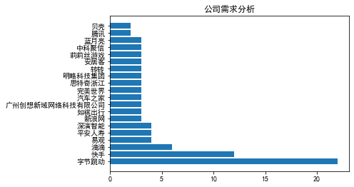

```python
#导包
import matplotlib.pyplot as plt

# 这两行代码解决中文显示的问题
plt.rcParams['font.sans-serif'] = ['SimHei']
plt.rcParams['axes.unicode_minus'] = False

company = com1.index
number = com1.values

plt.barh(company, number) # 横放条形图函数 barh
plt.title('公司需求分析')

plt.show()
```

我们可以看出互联网企业对数据分析岗位需求偏多。最多的是字节跳动，其次为快手、滴滴等。

**（2）地理位置统计-哪些城市对数据分析岗位需求大？**

```python
place = data['工作地点'].value_counts()
```

```python
place.values
```

```
array([142,  80,  39,  39,  20,  14,  10,   3,   2,   2,   2,   2,   2,
         2,   1,   1,   1], dtype=int64)
```

```python
import pyecharts.charts as pyec
x = list(place.index)
y = [142,  80,  39,  39,  20,  14,  10,   3,   2,   2,   2,   2,   2,
         2,   1,   1,   1]
bar=pyec.Bar()
bar.add_xaxis(x)
bar.add_yaxis('数量',yaxis_data=y)
bar.render_notebook()
```

我们可以看出，在国内，北京、上海、深圳、广州对此岗位需求量比较大。

**（3）薪资水平统计-该岗位一般处于什么薪资水平？**  
我们可以看出薪资这一列也需要处理一下数据。

```python
data['薪资区间']
```

```
0       18k-35k
1        8k-15k
2      20k-30k
3      20k-30k
4       30k-60k
         ...
357    16k-28k
358     15k-25k
359    10k-20k
360     10k-15k
361    13k-19k
Name: 薪资区间, Length: 362, dtype: object
```

```python
def salary_count(x):
    x_min,x_max = x.split('-')  #获取-两边的最大最小值
    x_min = int(x_min.replace('k','000'))
    x_max = int(x_max.replace('k','000')) #截取字符串，把k改成000，将字符串转化为数字
    if x_min == 0:
        x_min = 1    #除数不能为0
    return np.mean([x_min,x_max])
```

```python
#选取北上广深四个城市进行岗位平均工资分析

city = ['北京','上海','广州','深圳']

salary1 = data[data['工作地点']=='北京']
salary2 = data[data['工作地点']=='上海']
salary3 = data[data['工作地点']=='广州']
salary4 = data[data['工作地点']=='深圳']
```

```python
salary1 = np.array(salary1['薪资区间'].apply(salary_count)).mean()
salary2 = np.array(salary2['薪资区间'].apply(salary_count)).mean()
salary3 = np.array(salary3['薪资区间'].apply(salary_count)).mean()
salary4 = np.array(salary4['薪资区间'].apply(salary_count)).mean()
```

```python
salary = [salary1,salary2,salary3,salary4]
salary
```

```
[24380.281690140844, 19956.25, 16833.333333333332, 17628.20512820513]
```

```python
bar=pyec.Bar()
bar.add_xaxis(city)
bar.add_yaxis('平均工资',salary)
bar.render_notebook()
```

从图表中我们可以看出，北京行业平均工资最高，达24380元，广州在 四个城市里最低，为16833元。

**（4）学历要求统计-该岗位一般要求学历多高？**

```python
data['学历要求'].value_counts()
```

```
本科及以上    330
大专及以上     14
学历不限      10
硕士及以上      8
Name: 学历要求, dtype: int64
```

```python
from pyecharts import options as opts
x =  ['硕士','本科','大专','不限']
y =  [8,330,14,10]

c = (
    Pie()
    .add("", [list(z) for z in zip(x,y)])
    .set_global_opts(title_opts=opts.TitleOpts(title="岗位学历需求"))
    .set_series_opts(label_opts=opts.LabelOpts(formatter="{b}: {c}"))
)
c.render_notebook()
```

从图表中可以看出，数据分析岗位对于学历要求大多数是本科。

**（5）经验要求统计-该岗位一般需要多少年的经验？**

```python
data['工作经验'].value_counts()
```

```
经验3-5年     143
经验1-3年     108
经验5-10年     55
经验不限        33
在校应届        19
经验1年以下       4
Name: 工作经验, dtype: int64
```

```python
x =  ['应届生','不限','一年以下','1-3年','3-5年','5-10年']
y =  [19,33,4,108,143,55]

c = (
    Pie()
    .add("", [list(z) for z in zip(x,y)])
    .set_global_opts(title_opts=opts.TitleOpts(title="岗位经验需求"))
    .set_series_opts(label_opts=opts.LabelOpts(formatter="{b}: {c}"))
)
c.render_notebook()
```

基本大部分都要1-3年或者3-5年的经验才行。

**（6）岗位类别/福利一览**

```python
import jieba  #这里用了jieba分词
import matplotlib.pyplot as plt
from wordcloud import WordCloud
text = ' '.join(data['类别'])
cut_text = ' '.join(jieba.cut(text, cut_all=False, HMM=True))
```

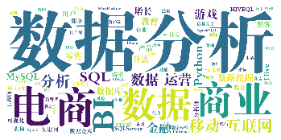

```python
font = r'C:\Windows\Fonts\FZDBSJW.TTF'
wc = WordCloud(background_color='white',  #背景设置为白色
               width=1300, height=620,
               font_path=font,
              max_font_size=1000) #这里要设置字体不然显示不出来
wordcloud = wc.generate(cut_text)
plt.imshow(wordcloud)
plt.axis('off') # 不显示坐标
plt.show()
```

可以看出很大一部分都是数据、电商、商业类别的，可以看到互联网占据了一部分，要求技术大部分为BI、mysql、python等。

```python
text = ' '.join(data['职位诱惑'])
cut_text = ' '.join(jieba.cut(text, cut_all=False, HMM=True))
```

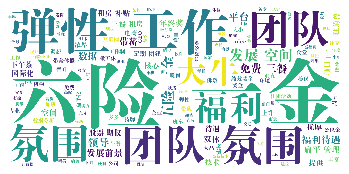

```python
font = r'C:\Windows\Fonts\FZDBSJW.TTF'
wc = WordCloud(background_color='white',  #背景设置为白色
               width=1300, height=620,
               font_path=font,
              max_font_size=300) #这里要设置字体不然显示不出来
wordcloud = wc.generate(cut_text)
plt.imshow(wordcloud)
plt.axis('off') # 不显示坐标
plt.show()
```

**（7）招聘分布一览**

```python
from pyecharts.charts import Geo
from pyecharts import options as opts
from pyecharts.charts import Geo
from pyecharts.globals import ChartType, SymbolType

x = list(place.index)
y = [142,  80,  39,  39,  20,  14,  10,   3,   2,   2,   2,   2,   2,
         2,   1,   1,   1]

# 链式调用
c = (
    Geo()
    # 加载图表模型中的中国地图
    .add_schema(maptype="china")
    # 在地图中加入点的属性
    .add("招聘",[list(z) for z in zip(x,y)])
    # 设置坐标属性
    .set_series_opts(label_opts=opts.LabelOpts(is_show=False))
    # 设置全局属性
    .set_global_opts(
        visualmap_opts=opts.VisualMapOpts(),
        title_opts=opts.TitleOpts(title="招聘地址"),
    )
)

# 在 Jupyter Notebook 中渲染图表
c.render_notebook()
```

```python
data['薪资区间'] = data['薪资区间'].apply(salary_count)
```

```python
data.rename(columns={'薪资区间':'薪资水平'},inplace=True)
```

```python
data
```

|  | 招聘单位 | 薪资水平 | 工作经验 | 学历要求 | 类别 | 职位诱惑 | 工作地点 |
| --- | --- | --- | --- | --- | --- | --- | --- |
| 0 | 陌陌 | 26500.0 | 经验3-5年 | 学历不限 | \| 数据分析 \| | 核心营收团队 | 北京 |
| 1 | 乐易网络 | 11500.0 | 经验1年以下 | 本科及以上 | \| 游戏 \| 移动互联网 \| 数据分析 \| 消费者分析 \| 市场分析 \| 商业分析 \| | 丰厚年终奖，年度调薪，高配团队，带薪假期 | 深圳 |
| 2 | 字节跳动 | 25000.0 | 经验3-5年 | 本科及以上 | \| 数据分析 \| | 弹性工作,免费三餐,租房补贴,带薪休假 | 上海 |
| 3 | KLOOK 客路旅行 | 25000.0 | 经验5-10年 | 本科及以上 | \| 电商 \| | 独角兽；D+轮融资 | 深圳 |
| 4 | 快手 | 45000.0 | 经验5-10年 | 本科及以上 | \| 数据分析 \| 风险控制 \| | 大牛云集，核心项目，发展空间巨大 | 北京 |
| ... | ... | ... | ... | ... | ... | ... | ... |
| 357 | 米雅 | 22000.0 | 经验3-5年 | 本科及以上 | \| 新零售 \| 大数据 \| 商业 \| BI \| 数据运营 \| 数据分析 \| | 上升空间大，团队氛围好 | 北京 |
| 358 | 瑞小云 | 20000.0 | 经验3-5年 | 本科及以上 | \| Python \| 数据挖掘 \| | 年终多薪，绩效奖金，团体旅游 | 苏州 |
| 359 | 新东方教育科技集团 | 15000.0 | 经验不限 | 本科及以上 | \| 教育 \| 数据分析 \| | 行业**；发展前景大。 | 北京 |
| 360 | 滴滴 | 12500.0 | 经验3-5年 | 本科及以上 | \| 数据分析 \| | 扁平化管理 六险一金 弹性上班 | 成都 |
| 361 | 平安好学 | 16000.0 | 经验3-5年 | 本科及以上 | \| 教育 \| ETL \| | 五险一金,带薪年假,定期体检,高温补贴 | 上海 |

362 rows × 7 columns

```python
#把整理好的数据保存在csv文件中
c = ['招聘单位','薪资水平','工作经验','学历要求','工作地点']
new_data = data[c]
```

```python
new_data
```

|  | 招聘单位 | 薪资水平 | 工作经验 | 学历要求 | 工作地点 |
| --- | --- | --- | --- | --- | --- |
| 0 | 陌陌 | 26500.0 | 经验3-5年 | 学历不限 | 北京 |
| 1 | 乐易网络 | 11500.0 | 经验1年以下 | 本科及以上 | 深圳 |
| 2 | 字节跳动 | 25000.0 | 经验3-5年 | 本科及以上 | 上海 |
| 3 | KLOOK 客路旅行 | 25000.0 | 经验5-10年 | 本科及以上 | 深圳 |
| 4 | 快手 | 45000.0 | 经验5-10年 | 本科及以上 | 北京 |
| ... | ... | ... | ... | ... | ... |
| 357 | 米雅 | 22000.0 | 经验3-5年 | 本科及以上 | 北京 |
| 358 | 瑞小云 | 20000.0 | 经验3-5年 | 本科及以上 | 苏州 |
| 359 | 新东方教育科技集团 | 15000.0 | 经验不限 | 本科及以上 | 北京 |
| 360 | 滴滴 | 12500.0 | 经验3-5年 | 本科及以上 | 成都 |
| 361 | 平安好学 | 16000.0 | 经验3-5年 | 本科及以上 | 上海 |

362 rows × 5 columns

```python
new_path = 'C:/Users/安雅沛/Desktop/拉勾网-招聘信息采集1.csv'
new_data.to_csv(new_path,encoding = 'utf-8',index=False)
```

```python
new_data1 = pd.read_csv(new_path,encoding = 'utf-8')
```

```python
new_data1
```

|  | 招聘单位 | 薪资水平 | 工作经验 | 学历要求 | 工作地点 |
| --- | --- | --- | --- | --- | --- |
| 0 | 陌陌 | 26500.0 | 经验3-5年 | 学历不限 | 北京 |
| 1 | 乐易网络 | 11500.0 | 经验1年以下 | 本科及以上 | 深圳 |
| 2 | 字节跳动 | 25000.0 | 经验3-5年 | 本科及以上 | 上海 |
| 3 | KLOOK 客路旅行 | 25000.0 | 经验5-10年 | 本科及以上 | 深圳 |
| 4 | 快手 | 45000.0 | 经验5-10年 | 本科及以上 | 北京 |
| ... | ... | ... | ... | ... | ... |
| 357 | 米雅 | 22000.0 | 经验3-5年 | 本科及以上 | 北京 |
| 358 | 瑞小云 | 20000.0 | 经验3-5年 | 本科及以上 | 苏州 |
| 359 | 新东方教育科技集团 | 15000.0 | 经验不限 | 本科及以上 | 北京 |
| 360 | 滴滴 | 12500.0 | 经验3-5年 | 本科及以上 | 成都 |
| 361 | 平安好学 | 16000.0 | 经验3-5年 | 本科及以上 | 上海 |

362 rows × 5 columns